**Force**

|  | by Seungchul Lee iSystems Design Lab http://isystems.unist.ac.kr/ UNIST |
| --- | --- |

Table of Contents

# 1. Newton's First Law

- when no force acts on a body, it will remain at rest or maintain uniform motion
- when a force is applied to a body, it will change its state of motion

# 2. Netwon's Second Law

## 2.1. Force

- Vector

$$\begin{align*} \vec F &\propto \vec a \\ \vec F &= m \cdot \vec a\\ & \quad\uparrow\\ &\text{Constant} \end{align*}$$

- $\vec F$ is proportinal to $\vec a$, and $m$ is nothing but a constant
- invisible
- change of velocity
- Mass is different from weight

### Same force

|  | $$\begin{align*} m_1 & a_1 \\ m_2 & a_2 \\ \\ m_1 a_1 &= m_2 a_2 \end{align*}$$ |
| --- | --- |

### Same mass

|  | $$\begin{array} \quad & m &\\ F_1 & & a_1\\ F_2 & & a_2\\ &\vdots&\\ \\ \end{array}$$ $$ \frac{F_1}{a_1}=\frac{F_2}{a_2}=m $$ |
| --- | --- |

- Newton's 2nd Law

$$\begin{array}{c} \vec F = m \vec a\\ \end{array}$$

- Mass is resistance to rate of change of velocity

## 2.2. Free Body Diagram (F.B.D.)

- Force is a vector concept
- Total force (or net force) is a vector sum of individual forces acting on the body from surroundings
- Consider one object (the system of interest)

[figure not shown]

$$\vec F_T = \sum\limits_{i} \vec{F}_i$$

```matlab
%%html
<center><iframe src="https://www.youtube.com/embed/pcFtlYNq2O0?list=PLBD_gON7g_m1ZBQxsjMPckhutDgGrzBj3"
width="560" height="315" frameborder="0" allowfullscreen></iframe></center>
```

[video not shown]

```matlab
%%html
<center><iframe src="https://www.youtube.com/embed/cTQ7lDGWgDg?list=PLBD_gON7g_m1ZBQxsjMPckhutDgGrzBj3"
width="560" height="315" frameborder="0" allowfullscreen></iframe></center>
```

[video not shown]

## 2.3. Gravitational force near the Earth

$$ \begin{align*} \vec g &\equiv \text{ gravitational force acting on an unit mass} \\ \vec F &= m \vec g \text{ : gravitational force acting on mass } m \end{align*}$$

[figure not shown]

$$F = m \cdot a$$$$\therefore \; \space a = g$$

- can be used to generate a constant force (or constant acceleration)

[figure not shown]

## 2.4. Normal force

- Perpendicular to the surface (surface being a plane) of *contact*
- Here *normal* refers to the geometry terminology for being perpendicular

[figure not shown]

## 2.5. Spring force (Hooke's law)

```matlab
%%html
<center><iframe src="https://www.youtube.com/embed/9BRUEIHwaU0"
width="420" height="315" frameborder="0" allowfullscreen></iframe></center>
```

[video not shown]

| $$\begin{align*} & \Large F = -kx \\ &\text{(idealized)} \end{align*}$$ |  |
| --- | --- |

- Force is proportional to a displacement (the amount of deformation)
  - example: a scale
- negative sign: restoring force (directed back toward the equilibrium position of the system)
- an idealized spring is a linear device that can generate force $F = -kx$

[figure not shown]

| $$\text{F.B.D.}$$ $$F = -kx$$ | $$\text{Kinematics}$$ $$\underrightarrow{+} \quad a$$ |
| --- | --- |

$$ \begin{align*} F &= ma \\ -kx &= ma \end{align*}$$

- acceleration is changing over time or displacement (not a constant acceleration any more)

$$ -kx = m\frac{d^2x}{dt^2} \implies m\frac{d^2x(t)}{dt^2} + kx(t) = 0$$

```matlab
%%html
<center><iframe src="https://www.youtube.com/embed/KjTa6b6mCv4"
width="420" height="315" frameborder="0" allowfullscreen></iframe></center>
```

[video not shown]

### Numerical solution of simple harmonic motion

```matlab
m = 1.0;    % kg
k = 100.0;    % N/m
g = 9.8;    % m/sˆ2
v0 = 0.0;    % in m/s
time = 2.0;    % s
dt = 0.0001; % s
n = ceil(time/dt);
t = zeros(n,1);
y = zeros(n,1);
v = zeros(n,1);
a = zeros(n,1);
y(1) = 0.0;
v(1) = v0;
a(1) = -k*y(1) - m*g;

for i = 1:n-1
    F = -k*y(i) - m*g;
    a(i+1) = F/m;
    v(i+1) = v(i) + a(i+1)*dt;
    y(i+1) = y(i) + v(i+1)*dt;
    t(i+1) = t(i) + dt;
end
```

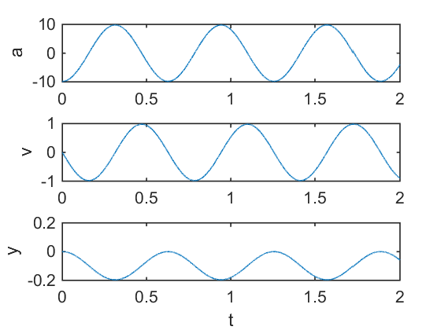

```matlab
subplot(3,1,1), plot(t,a), ylabel('a')
subplot(3,1,2), plot(t,v), ylabel('v')
subplot(3,1,3), plot(t,y), ylabel('y'), xlabel('t')
```

[figure not shown]

# 3. Newton’s Third Law: Action-Reaction Pairs

- When two bodies interact via a force, then the force on one body is equal in magnitude and opposite in direction to the force acting on the other body

[figure not shown]

$$\vec{F}_{1,2} = - \vec{F}_{2,1}$$

**Question**

Consider a car at rest on a level surface. We can conclude that the downward gravitational pull of Earth on the car and upward contact force of Earth on it are equal and opposite because

1. The two forces from an interaction pair
2. The net force on the car is zero
3. Neither of the above
4. Unsure

## 3.1. Example

- Think about all forces acting on $m$
  - $mg$, pulled down by the earth (non-contact)
  - $N$, pushed up by the table (contact)
- $m$ is at rest $(a = 0)$

  $\implies $ No total external forces $(N = mg)$
- Action & Reaction forces between two objects

[figure not shown]

## 3.2. Example - push

[figure not shown]

| $$\text{Person}$$ | $$\text{Bar}$$ | $$\text{Wall}$$ |
| --- | --- | --- |

$$\lvert F \rvert = \lvert F_{\text{friction}} \rvert = \lvert F_{\text{wall}} \rvert$$

## 3.3. Example - pull

Person $A$ is pulling a string with force $F$. Tell all forces

[figure not shown]

- String

|  | $$ \begin{array}{l} F_1 \text{ (by wall) }\\ a_s = 0 \end{array} $$ |
| --- | --- |

$\implies F_1 = F \text{ [from Newton's } 2^{nd} \text{ Law] }$

- Wall

|  | $$ \text{A wall is pulling a string by $F$}$$ $$\begin{align*} \\ M_w a_w &= F \\ a_w &= 0 \quad (\because M \rightarrow \infty) \end{align*}$$ |
| --- | --- |

$\implies \text{ A string is pulling a wall by } F \text{ [from Newton's } 3^{rd} \text{ Law]}$

- Persion A

|  | $$\text{A string is pulling person A by } F \text{ [from Newton's } 3^{rd} \text{ Law]}$$ |
| --- | --- |

$$a_A = 0 $$$$\text{Why?} \quad \text{Friction}$$

[figure not shown]

**Question**

A body of mass $m$ is suspended from a spring with spring constant $k$ in configuration (a) and the spring is stretched $0.1$m. If two identical bodies of mass $\frac{m}{2}$ are suspended from a spring with the same spring constant $k$ in configuration (b), how much will the spring stretch? Explain your answer.

[figure not shown]

## Exercises

**Problem 1**

[figure not shown]

**Problem 2**

[figure not shown]

**Problem 3**

Find $\vec a$ for $m$ and $M$

[figure not shown]

# 4. Reference Frame

[figure not shown]

**Inertial Reference Frame**

- $A$'s point of view ($A$ reference)

$$\begin{array}{l} A \text{: at rest}\\ B \text{: moves with } +a \end{array} \quad \text{Apply the } 2^{nd} \text{ Law}$$

[figure not shown]

**Non Inertial Reference Frame**

- $B$'s point of view ($B$ reference)

$$ \begin{array}{l} B\text{: at rest}\\ A\text{: moves with } - a_B \end{array}$$

[figure not shown]

- Is Newton’s Law wrong ?
  - Observation (reference) frame is accelerating !!!
  - Frame moves with $a_B$

[figure not shown]

$$F - m_Ba_B = m_B \cdot 0$$

[figure not shown]

$$-m_Aa_B = m_A(-a_B)$$

```matlab
%%html
<center><iframe src="https://www.youtube.com/embed/My2z65pkpuM"
width="560" height="315" frameborder="0" allowfullscreen></iframe></center>
```

[video not shown]

```matlab
%%html
<center><iframe src="https://www.youtube.com/embed/y8mzDvpKzfY"
width="560" height="315" frameborder="0" allowfullscreen></iframe></center>
```

[video not shown]

```matlab
%%html
<center><iframe src="https://www.youtube.com/embed/FjuMvUbT8gA"
width="560" height="315" frameborder="0" allowfullscreen></iframe></center>
```

[video not shown]

**Summary**

```matlab
%%html
<center><iframe src="https://www.youtube.com/embed/z0ijwmYLHhw?list=PLBD_gON7g_m17lIledteTg4CeySTCbEsc"
width="560" height="315" frameborder="0" allowfullscreen></iframe></center>
```

[video not shown]

```matlab
%%html
<center><iframe src="https://www.youtube.com/embed/HoCLWQApN1M?list=PLBD_gON7g_m17lIledteTg4CeySTCbEsc"
width="560" height="315" frameborder="0" allowfullscreen></iframe></center>
```

[video not shown]

**Problem 3 revisited**

Find $\vec a$ for $m$ and $M$

[figure not shown]

# 5. What is Weight?

## 5.1. Weight

[figure not shown]

$$N - mg = m \cdot 0$$

|  | $$\text{Spring is compressed by } x$$ $$N = + kx \\$$ $$\text{Weight = Normal force on a scale}$$ |
| --- | --- |

## 5.2. Inside elevator

### Example - Weight with an upward accelerating Elevator

[figure not shown]

$$\begin{align*} N - mg &= ma\\ N &= m(g+a)\\ \\ \implies &\text{gain weight} \end{align*}$$

### Example – Weight observed inside an upward Accelerating Elevator

[figure not shown]

$$N - mg - ma = 0$$

```matlab
%%html
<center><iframe src="https://www.youtube.com/embed/D-GzuZjawNI"
width="420" height="315" frameborder="0" allowfullscreen></iframe></center>
```

[video not shown]

```matlab
%%html
<center><iframe src="https://www.youtube.com/embed/etcZNxQPPaY"
width="420" height="315" frameborder="0" allowfullscreen></iframe></center>
```

[video not shown]

## 5.3. What is weight in tension?

[figure not shown]

|  | $$T - mg = ma$$ |
| --- | --- |

## 5.4. Force in a circular motion

**Example – Inertial circular frame**

[figure not shown]

$$N = mr\omega^2$$

**Example – Non inertial circular frame**

[figure not shown]

$$a = 0$$$$ - N + mr\omega^2 = m\cdot0$$$$a_{f_2} \text{ : feels like a gravitatial acceleration}$$

**Problem**

[figure not shown]

**Problem**

[figure not shown]

# 6. Problems with Pulleys

[figure not shown]

Ignore (mass, moment of inertia) of a pulley $\implies$ It only changes directions

## 6.1. Tension on a string is uniform (?)

Think of a small piece of string segment

[figure not shown]

$$ \begin{align*} \text{if } T_1 &\neq T_2\\ T_1 - T_2 &= ma \end{align*} \quad \text{: might have almost infinite acceleration} $$

## 6.2. Example - pulley

[figure not shown]

# 7. Question on Newton's Law

```matlab
%%html
<center><iframe src="https://www.youtube.com/embed/_TeW04Le-rg"
width="420" height="315" frameborder="0" allowfullscreen></iframe></center>
```

[video not shown]

# 8. Angular Dynamics on Circular Motion

We begin our discussion of rotational dynamics and rotational motion. We will start by introducing the concept of torque, the new manifestation of forces that produce a change in rotational motion.

- Interactions $\rightarrow$ Force $\rightarrow$ Change in **translational** motion

To include rotational motion, the net torque applied to a rigid body will produce a change in rotational motion:

- Interactions $\rightarrow$ Force $\rightarrow$ Torque $\rightarrow$ Change in **rotational** motion

## 8.1. Kinematics on circular motion

$$ \begin{align*}\displaystyle \omega(t) &= \frac{d\theta(t)}{dt} &\text{units:}\, [\omega]=\text{rad/s}\\ \displaystyle \alpha(t) &= \frac{d\omega(t)}{dt} = \frac{d^{2}\theta(t)}{dt^2} &\text{units:}\, [\alpha] = \text{rad/s}^2\end{align*}$$

## 8.2. Torque about an Axis

In our study of translational motion under force, the location where the force was applied to the system did not matter. The subsequent translational motion only depended on the magnitude and direction of the net force. We will see that this simplification no longer holds for rotational motion. Forces applied to a body in an attempt to produce rotation will have different effects depending on the location of application and the direction of the applied force.

Consider trying to close a door by applying a force to the door near the hinges or in the middle of the door. Getting the door to close is much easier when the force is applied far from the hinges (see force $F_3$ in the figure below). This is why we usually place door handles by the edge opposite the hinges.

A well chosen location is not enough to guarantee effective rotation from an applied force. Consider another experiment. Suppose that you stand at the edge of an open door and push the door edge toward the hinges (see the force $F_1$ in the figure below). The door will not rotate, even with a hard push. This indicates that the direction of the force also affects the rotation produced.

[figure not shown]

**Definition of Torque**

$$\begin{align} \vec{\tau} = \vec{r}\times \vec{F} \end{align}$$

where the vector $\vec{r}$ is the position vector of the point **A** measured from point **Q**. (see below).

| $$\begin{align*} \tau_{net} &\,\text{ causes }\,\alpha\\ \tau_{net} &= I \cdot \alpha \end{align*} $$ | $$\begin{align*} \text{like } \, F_{net} &\,\text{ causes }\,a\\ \text{like } \, F_{net} &= m \cdot a \end{align*} $$ |
| --- | --- |

$$ \begin{align*} \tau &= rF = I \alpha = mr^2 \alpha\\ &\implies F = m \cdot r \alpha \\ &\implies F = m a \end{align*} $$

## 8.3. Torque = Moment

- How can we generate the moment?
- Vector
  - Magnitude
  - Direction (not obvious)

[figure not shown]

```matlab
%%html
<center><iframe src="https://www.youtube.com/embed/qDjZf7O20Cg"
width="560" height="315" frameborder="0" allowfullscreen></iframe></center>
```

[video not shown]

## 8.3. Moment of Inertia

moment of inertia = roational mass
$$I = \sum_{i} m_i r_i^2$$

Just as mass quantifies the resistance of an object to changes in linear velocity, the moment of inertia, also called rotational inertia, quantifies the resistance of an object to changes in angular velocity. A system's moment of inertia depends on

- about what axis the system rotates,
- the mass of the system,
- how the mass is distributed—is it far from the rotation axis, or near the rotation axis?

moment of inertia for other rigid bodies

[figure not shown]

```matlab
%%html
<center><iframe src="https://www.youtube.com/embed/zesZg4FutAE"
width="560" height="315" frameborder="0" allowfullscreen></iframe></center>
```

[video not shown]

**Analogy of Rotational Dynamics with Translation Dynamics (Newton's Second Law)**

By analogy to the manner in which force changes velocity

$$\sum\vec{F}=m \frac{d \vec{v}}{dt} =m\vec{a}$$

the angular dynamics and net torque model has a similar equation of change, but for rotational velocity around a fixed axis. If we apply a non zero torque on an object (e.g. push or pull on a door handle), it will result in a change of rotational motion - e.g. the door will start to rotate faster or slower about its (fixed) hinges.

By analogy, the angular velocity of an object rotating about an axis that passes through a point $Q$, is changed by the net torque on the object measured about point Q:

$$\sum\vec{\tau}_{\small{Q}} = I_Q \frac{d \vec \omega}{dt} = I_Q \vec{\alpha}$$

Where $\alpha$ is the angular acceleration: the rate of change of the angular speed $\omega$, and $\displaystyle I_Q$ is the moment of inertia about point $Q$, a quantity that is analogous to the inertial mass in $\sum\vec{F}=m\vec{a}$.

```matlab
%%javascript
$.getScript('https://kmahelona.github.io/ipython_notebook_goodies/ipython_notebook_toc.js')
```